```
                                  M504 AI  and Applications
```

# Exploratory Data Analysis of European Retail Sales

Fereshteh Safarkhani, Student ID: GH1031192

# INTRODUCTION & BUSINESS CONTEXT

This report looks at sales data from different European countries. The goal is to understand how the business is doing and find areas to improve. By analyzing product categories, countries, sales channels, order priorities, and time-based trends, we can figure out where the company is making the most money and where there are opportunities to do better.

The data includes things like sales channels (Online and Offline), countries, order dates, profits, revenues, and product categories. Using this data, we answer some key business questions that can help managers make smarter decisions about what to focus on, where to sell, and how to improve performance.

# **Business Questions**

1. Which product categories generate the highest revenue and profit?
2. Are there seasonal or monthly patterns in sales and profit performance?
3. How do online and offline sales channels compare in units sold, revenue, and profit?
4. Which countries have the highest and lowest total profit and profit margins?
5. How does order priority impact revenue, profit, and delivery times?

# **Dataset Overview**

The [dataset](https://www.kaggle.com/datasets/mustafabayar/europe-sales-records) contains 1,436 records and 14 columns of individual sales transactions in Europe. Each record has essential information such as the country where the sale took place, the type of product sold, the order priority level, the sales channel used (online or offline), and various financial metrics. These metrics include the number of units sold, unit price, total revenue, total cost, and total profit.

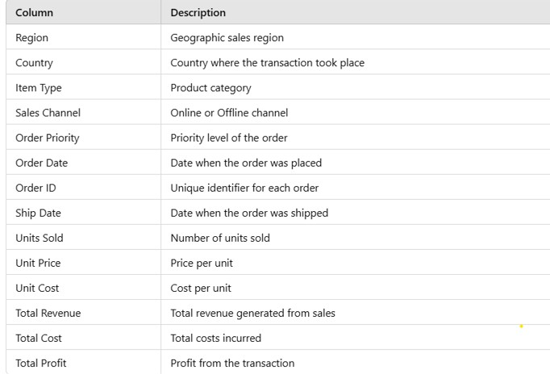

# **Data Cleaning & Exploration**

# Import Libraries

I'm using pandas to work with the data, numpy for numbers, and matplotlib & seaborn to make charts

- **pandas** for data manipulation and cleaning
- **NumPy** for numerical operations
- **matplotlib & seaborn** for visualizations that simplify pattern detection

```python
import pandas as pd
import numpy as np
import matplotlib.pyplot as plt
import seaborn as sns
```

# Reading dataset

```python
df = pd.read_excel("/content/drive/MyDrive/Europe_Sales.xlsx")
print("Dataset shape:", df.shape)
df.head(3)
```

```
Dataset shape: (1436, 14)
```

|  | Region | Country | Item Type | Sales Channel | Order Priority | Order Date | Order ID | Ship Date | Units Sold | Unit Price | Unit Cost | Total Revenue | Total Cost | Total Profit |
| --- | --- | --- | --- | --- | --- | --- | --- | --- | --- | --- | --- | --- | --- | --- |
| 0 | Europe | Czech Republic | Beverages | Offline | C | 9/12/2011 | 478051030 | 9/29/2011 | 4778.0 | 47.45 | 31.79 | 226716.10 | 151892.62 | 74823.48 |
| 1 | Europe | Bosnia and Herzegovina | Clothes | Online | M | 10/14/2013 | 919133651 | 11/4/2013 | 927.0 | 109.28 | 35.84 | 101302.56 | 33223.68 | 68078.88 |
| 2 | Europe | Austria | Cereal | Offline | C | 8/13/2014 | 987410676 | 9/6/2014 | 5616.0 | 205.70 | 117.11 | 1155211.20 | 657689.76 | 497521.44 |

Here, I load the dataset for demonstration into a DataFrame and confirm how many rows and columns it has.

# Checking & Handling Missing Values

Before jumping into the analysis, I made sure there was no missing data that could mess things up

```
Region             0
Country           29
Item Type         72
Sales Channel      0
Order Priority     0
Order Date         0
Order ID           0
Ship Date          0
Units Sold        25
Unit Price        43
Unit Cost          0
Total Revenue      0
Total Cost         0
Total Profit      33
dtype: int64
```

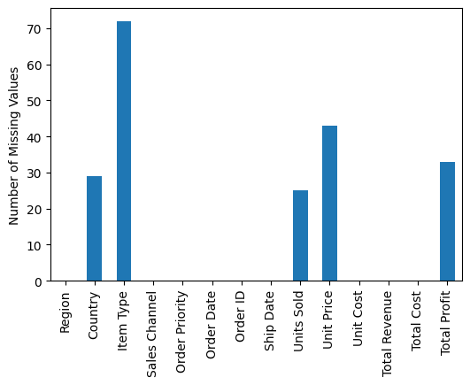

```python
missing_counts = df.isnull().sum()
print(missing_counts)
missing_counts.plot(kind='bar', figsize=(6,4))
plt.ylabel("Number of Missing Values")
plt.show()
```

```python
df["Region"].unique()
```

```
array(['Europe', 'Unknown_Region'], dtype=object)
```

```python
df['Region'].value_counts()
```

| Region | count |
| --- | --- |
| Europe | 1421 |
| Unknown_Region | 15 |

**dtype:** int64

The Region column didn’t have missing values, but I found 15 rows with 'Unknown_Region

# Strategy for Categorical Columns

Country and Item Type had some gaps, so I filled them with the most common value. It was the easiest fix. here were some 'Unknown' values in Region too, so I just replaced them with Europe since it was the most common.

```python
region_mode = df['Region'].mode()[0]
country_mode = df['Country'].mode()[0]
item_type_mode = df['Item Type'].mode()[0]

df['Country'] = df['Country'].fillna(country_mode)
df['Item Type'] = df['Item Type'].fillna(item_type_mode)

df['Region'] = df['Region'].replace('Unknown_Region', region_mode)
```

# Strategy for Numerical Columns

For numbers like Units Sold and Unit Price, I used the median to fill in the blanks. It works better when you have outliers.

```python
df['Units Sold'] = df['Units Sold'].fillna(df['Units Sold'].median())
df['Unit Price'] = df['Unit Price'].fillna(df['Unit Price'].median())
```

*For* Total Profit, instead of filling missing valuese, i used:

Total Profit = Total Revenue - Total Cost

```python
df['Total Profit'] = df['Total Revenue'] - df['Total Cost']
```

I double-checked to make sure there were no more missing values after fixing everything.

```python
print(df.isnull().sum())
```

```
Region            0
Country           0
Item Type         0
Sales Channel     0
Order Priority    0
Order Date        0
Order ID          0
Ship Date         0
Units Sold        0
Unit Price        0
Unit Cost         0
Total Revenue     0
Total Cost        0
Total Profit      0
dtype: int64
```

Now we handled all missing values

# Handling Duplicates

I checked for any repeated rows using duplicated() and dropped them.

```python
duplicates_before = df.duplicated().sum()

df.drop_duplicates(inplace=True)

duplicates_after = df.duplicated().sum()

print("Duplicates removed:", duplicates_before - duplicates_after)
```

```
Duplicates removed: 87
```

# Handling Outliers

I used boxplots to see which values were way too high or low. Then I decided if I should fix them or not

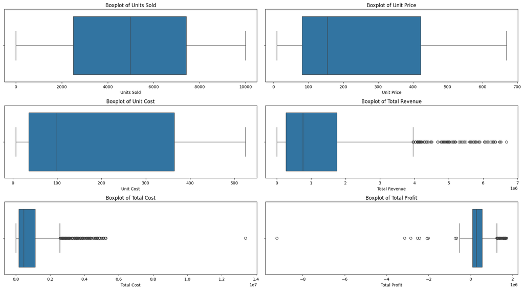

```python
numeric_features = ['Units Sold', 'Unit Price', 'Unit Cost', 'Total Revenue', 'Total Cost', 'Total Profit']

plt.figure(figsize=(18, 10))

for i, col in enumerate(numeric_features, 1):
    plt.subplot(3, 2, i)
    sns.boxplot(x=df[col])
    plt.title(f'Boxplot of {col}')

plt.tight_layout()
plt.show()
```

# Handle Outliers

"The boxplots showed some crazy high or low values in Total Revenue, Total Cost, and Total Profit. Instead of deleting them, I capped them at the 99th percentile." These were very high or negative values that could throw off the analysis by pulling the averages in the wrong direction.

Instead of removing those records, I took a more balanced approach and capped the extreme values at the 99th percentile. In simple terms, any value higher than that point was replaced with the 99th percentile value. This helps reduce the impact of outliers while keeping all the data in the analysis especially when comparing profits across regions, products, and sales channels.

```python
q99_total_cost = df['Total Cost'].quantile(0.99)
q99_total_revenue = df['Total Revenue'].quantile(0.99)

df['Total Cost'] = np.where(df['Total Cost'] > q99_total_cost, q99_total_cost, df['Total Cost'])

df['Total Revenue'] = np.where(df['Total Revenue'] > q99_total_revenue, q99_total_revenue, df['Total Revenue'])

print(f"New max Total Cost (capped): {df['Total Cost'].max()}")
print(f"New max Total Revenue (capped): {df['Total Revenue'].max()}")
```

```
New max Total Cost (capped): 4863935.4752
New max Total Revenue (capped): 6091804.2952
```

```python
q99_total_profit = df['Total Profit'].quantile(0.99)

df['Total Profit'] = np.where(df['Total Profit'] > q99_total_profit, q99_total_profit, df['Total Profit'])

print(f"New max Total Profit (capped): {df['Total Profit'].max()}")
```

```
New max Total Profit (capped): 1599506.6328
```

# Re-Visualize to Confirm

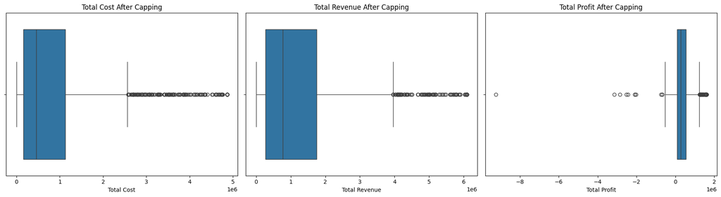

```python
plt.figure(figsize=(18, 5))

plt.subplot(1, 3, 1)
sns.boxplot(x=df['Total Cost'])
plt.title('Total Cost After Capping')

plt.subplot(1, 3, 2)
sns.boxplot(x=df['Total Revenue'])
plt.title('Total Revenue After Capping')

plt.subplot(1, 3, 3)
sns.boxplot(x=df['Total Profit'])
plt.title('Total Profit After Capping')

plt.tight_layout()
plt.show()
```

Total Profit is useful, but it doesn’t show how good we are at turning sales into profit. So, I added Profit Margin (%) to make it easier to compare stuff.

```python
df['Profit Margin (%)'] = (df['Total Profit'] / df['Total Revenue']) * 100
```

With Profit Margin in place, it’s easier to look deeper into profits across countries, products, and channels.

# Exploratory Data Analysis (EDA)

I checked the basic stats to see if anything looked weird or if the numbers made sense.

```python
print("There are", df.shape[0], "rows and", df.shape[1], "columns in the data.")

df.describe()
```

```
There are 1349 rows and 15 columns in the data.
```

|  | Order ID | Units Sold | Unit Price | Unit Cost | Total Revenue | Total Cost | Total Profit | Profit Margin (%) |
| --- | --- | --- | --- | --- | --- | --- | --- | --- |
| count | 1.349000e+03 | 1349.000000 | 1349.000000 | 1349.000000 | 1.349000e+03 | 1.349000e+03 | 1.349000e+03 | 1349.000000 |
| mean | 5.425386e+08 | 4965.275019 | 260.839822 | 187.566820 | 1.280139e+06 | 9.252396e+05 | 3.489361e+05 | 31.255892 |
| std | 2.567403e+08 | 2872.720089 | 213.978036 | 176.217711 | 1.433640e+06 | 1.154283e+06 | 4.992960e+05 | 26.707073 |
| min | 1.006406e+08 | 2.000000 | 9.330000 | 6.920000 | 5.038200e+02 | 3.736800e+02 | -9.235016e+06 | -245.767854 |
| 25% | 3.225241e+08 | 2502.000000 | 81.730000 | 35.840000 | 2.665872e+05 | 1.628284e+05 | 8.017395e+04 | 24.799856 |
| 50% | 5.442849e+08 | 5005.000000 | 154.060000 | 97.440000 | 7.636629e+05 | 4.535588e+05 | 2.670982e+05 | 33.003161 |
| 75% | 7.542271e+08 | 7426.000000 | 421.890000 | 364.690000 | 1.743052e+06 | 1.122636e+06 | 5.434303e+05 | 39.768984 |
| max | 9.998797e+08 | 9999.000000 | 668.270000 | 524.960000 | 6.091804e+06 | 4.863935e+06 | 1.599507e+06 | 67.203514 |

The summary table shows profit margins are around 31% on average, but some sales did way better, and some lost money.

# Distribution of Profit Margin (%)

I checked how profit margins are spread across all sales to see if we're really making money or not.

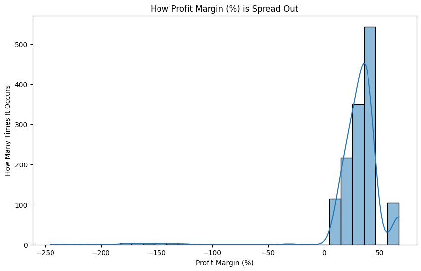

```python
plt.figure(figsize=(10,6))
sns.histplot(df['Profit Margin (%)'], bins=30, kde=True)
plt.title('How Profit Margin (%) is Spread Out')
plt.xlabel('Profit Margin (%)')
plt.ylabel('How Many Times It Occurs')
plt.show()
```

Overall, this gives us a good idea of how well the company is turning sales into actual profit.

# Correlation Between Variables

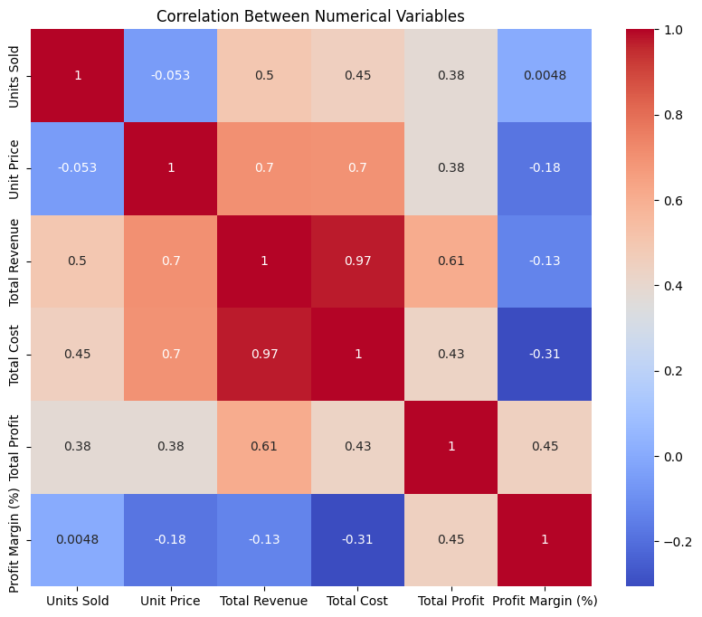

```python
corr_matrix = df[['Units Sold', 'Unit Price', 'Total Revenue', 'Total Cost', 'Total Profit', 'Profit Margin (%)']].corr()

plt.figure(figsize=(10,8))
sns.heatmap(corr_matrix, annot=True, cmap='coolwarm')
plt.title('Correlation Between Numerical Variables')
plt.show()
```

The chart also highlights a close relationship between Total Revenue and Total Cost (0.97), as well as a good connection between Revenue and Profit (0.61). This makes sense because when sales increase, revenue goes up, but expenses often rise too.

On the other hand, Profit Margin (%) behaves differently. Its weak or even negative correlation suggests that selling more doesn’t always lead to higher profitability.

# Business Questions and Answers

**Q1.Which product categories generate the highest revenue and profit?**

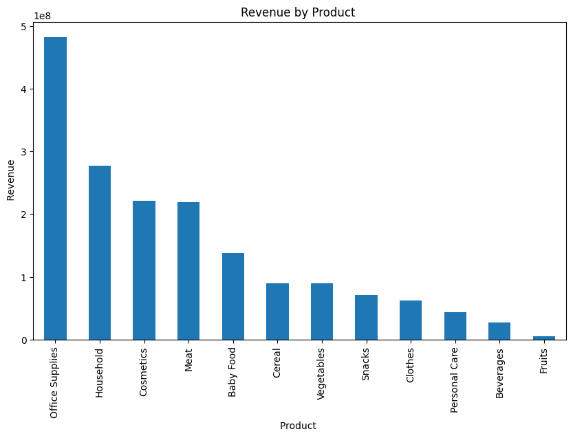

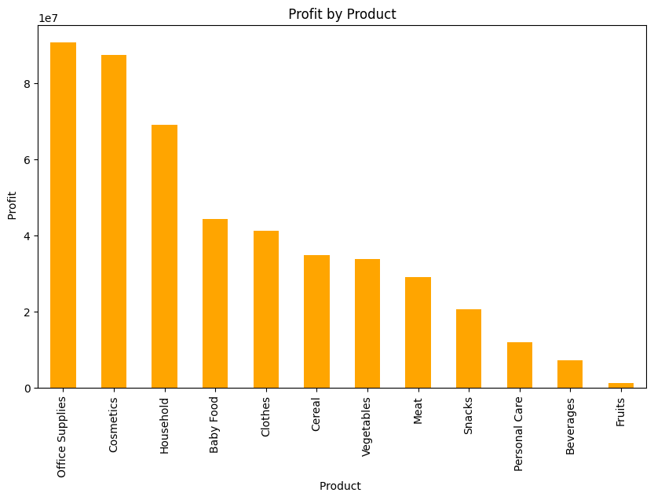

| Item Type | Total Revenue |
| --- | --- |
| Office Supplies | 4.822919e+08 |
| Household | 2.769725e+08 |
| Cosmetics | 2.211777e+08 |
| Meat | 2.191343e+08 |
| Baby Food | 1.376398e+08 |
| Cereal | 9.023113e+07 |
| Vegetables | 8.961054e+07 |
| Snacks | 7.072464e+07 |
| Clothes | 6.274836e+07 |
| Personal Care | 4.364864e+07 |
| Beverages | 2.753011e+07 |
| Fruits | 5.197249e+06 |

**dtype:** float64

| Item Type | Total Profit |
| --- | --- |
| Office Supplies | 9.064974e+07 |
| Cosmetics | 8.738294e+07 |
| Household | 6.895019e+07 |
| Baby Food | 4.418256e+07 |
| Clothes | 4.121314e+07 |
| Cereal | 3.469815e+07 |
| Vegetables | 3.378770e+07 |
| Meat | 2.898713e+07 |
| Snacks | 2.050309e+07 |
| Personal Care | 1.186295e+07 |
| Beverages | 7.272346e+06 |
| Fruits | 1.224795e+06 |

**dtype:** float64

```python
category_revenue = df.groupby('Item Type')['Total Revenue'].sum().sort_values(ascending=False)
category_profit = df.groupby('Item Type')['Total Profit'].sum().sort_values(ascending=False)

plt.figure(figsize=(10,6))
category_revenue.plot(kind='bar')
plt.title('Revenue by Product ')
plt.xlabel('Product ')
plt.ylabel(' Revenue')
plt.show()

plt.figure(figsize=(10,6))
category_profit.plot(kind='bar', color='orange')
plt.title(' Profit by Product ')
plt.xlabel('Product ')
plt.ylabel(' Profit')
plt.show()
```

The charts shows that not all product categories perform the same in revenue and profit.

Office Supplies are the best-performing category in terms of both revenue and profit. This is probably because they’re essential for many businesses and customers, which keeps demand high. They also seem to have a good balance between costs and prices, helping to increase profits.

Household and Cosmetics are doing okay. Household sells more, but Cosmetics make better profit margins even with less sales.

Fruits and Beverages are at the bottom. They don’t sell much and they don’t make much profit either. Maybe they’re too expensive to produce or people just aren’t buying them..

**Q2. Are there seasonal or monthly patterns in sales and profit performance?**

```
datetime64[ns]
```

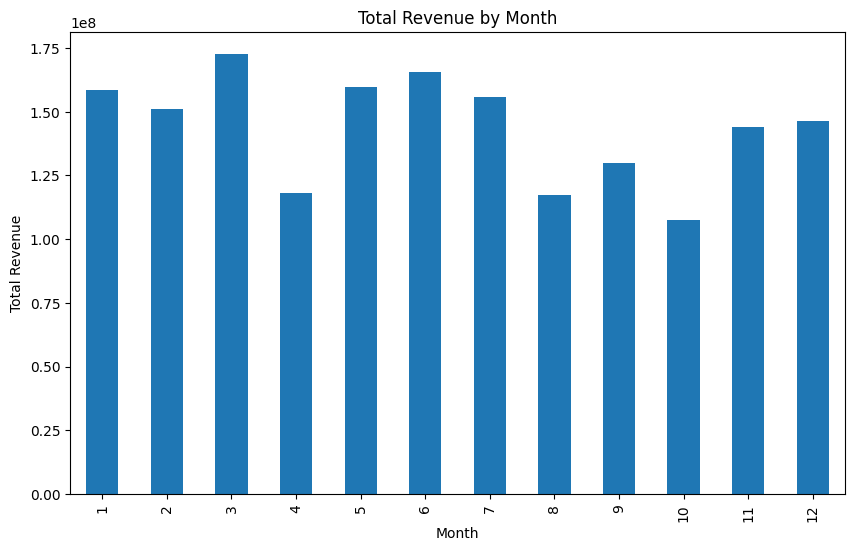

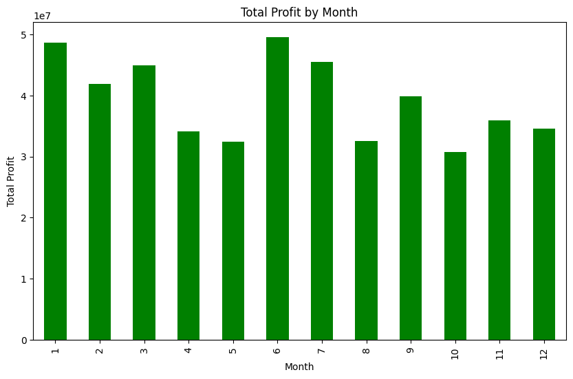

```python
df['Order Date'] = pd.to_datetime(df['Order Date'], errors='coerce')

print(df['Order Date'].dtypes)

df['Month'] = df['Order Date'].dt.month

monthly_sales = df.groupby('Month')['Total Revenue'].sum()
monthly_profit = df.groupby('Month')['Total Profit'].sum()

plt.figure(figsize=(10,6))
monthly_sales.plot(kind='bar')
plt.title('Total Revenue by Month')
plt.xlabel('Month')
plt.ylabel('Total Revenue')
plt.show()

plt.figure(figsize=(10,6))
monthly_profit.plot(kind='bar', color='green')
plt.title('Total Profit by Month')
plt.xlabel('Month')
plt.ylabel('Total Profit')
plt.show()
```

Sales and profit go up and down depending on the month. Some months are busy, others are slow.

**Q3. How do online and offline sales channels compare in units sold, revenue, and profit??**

|  | Sales Channel | Units Sold | Total Revenue | Total Profit |
| --- | --- | --- | --- | --- |
| 0 | Offline | 3378385.0 | 8.850128e+08 | 2.329865e+08 |
| 1 | Online | 3319771.0 | 8.418941e+08 | 2.377283e+08 |

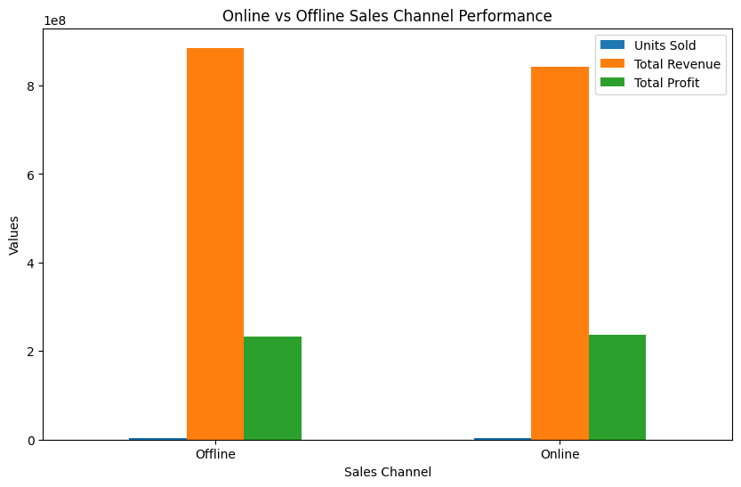

```
ANOVA F-statistic: 0.09957109987343356
ANOVA p-value: 0.7523938199282325
```

```python
channel_performance = df.groupby('Sales Channel').agg({
    'Units Sold': 'sum',
    'Total Revenue': 'sum',
    'Total Profit': 'sum'
}).reset_index()

display(channel_performance)

channel_performance.set_index('Sales Channel')[['Units Sold', 'Total Revenue', 'Total Profit']].plot(
    kind='bar',
    figsize=(10, 6)
)

plt.title('Online vs Offline Sales Channel Performance')
plt.ylabel('Values')
plt.xlabel('Sales Channel')
plt.xticks(rotation=0)
plt.show()

from scipy.stats import f_oneway

online_profit = df[df['Sales Channel'] == 'Online']['Total Profit']
offline_profit = df[df['Sales Channel'] == 'Offline']['Total Profit']

anova_result = f_oneway(online_profit, offline_profit)

print("ANOVA F-statistic:", anova_result.statistic)
print("ANOVA p-value:", anova_result.pvalue)
```

When comparing the performance of Online and Offline sales channels, there are some noticeable differences in both revenue and profit. The Offline channel has sold a bit more—about 3.37 million units—compared to 3.32 million units sold through the Online channel. Offline sales also brought in more total revenue, around 885 million, while Online sales made about 842 million. This suggests the Offline channel is contributing slightly more to overall sales.

However, when looking at total profit, the Online channel comes out ahead. Online sales generated about 237 million in profit, which is slightly more than the 232 million made from Offline sales. This could mean Online sales are more efficient, possibly due to lower operating costs or better profit margins.

To see if these differences are really meaningful or just random, we ran an ANOVA test. The test compared the average profit from both channels and gave an F-statistic of 0.09957 with a p-value of 0.75239. Since the p-value is much higher than 0.05, it shows there’s no real statistical difference between the profits from Online and Offline sales. In simple terms, the small differences we see in profit and revenue could just be normal variation, not a sign that one channel is actually better than the other.

From a business perspective, this means there’s no clear reason to prioritize one channel over the other based on profit alone. Both channels are performing similarly when it comes to profitability. Instead of shifting focus, the company could continue investing in both channels and look at other areas—like improving customer service, speeding up delivery, or refining marketing—to boost performance. It might also be a good idea to find ways to streamline and connect both sales channels to get the most out of both.

**Q4.Which countries have the highest and lowest total profit and profit margins?**

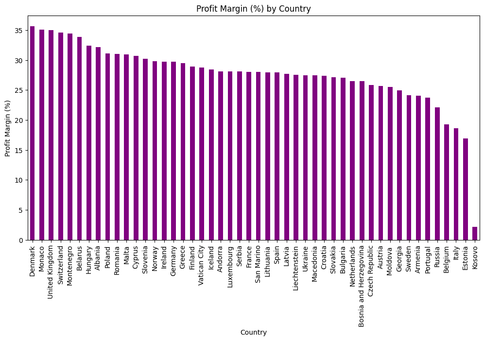

| Country | Profit Margin (%) |
| --- | --- |
| Denmark | 35.661629 |
| Monaco | 35.120437 |
| United Kingdom | 34.988992 |
| Switzerland | 34.626627 |
| Montenegro | 34.393922 |

**dtype:** float64

```python
country_group = df.groupby('Country').agg({
    'Total Profit': 'sum',
    'Total Revenue': 'sum'
})

country_group['Profit Margin (%)'] = (country_group['Total Profit'] / country_group['Total Revenue']) * 100

profit_margin_by_country = country_group['Profit Margin (%)'].sort_values(ascending=False)

plt.figure(figsize=(12, 6))
profit_margin_by_country.plot(kind='bar', color='purple')
plt.title('Profit Margin (%) by Country')
plt.xlabel('Country')
plt.ylabel('Profit Margin (%)')
plt.show()

profit_margin_by_country.head()
```

The analysis of profit margins by country shows clear differences in how efficiently each country turns sales into profit. Based on the chart and data:

Denmark has the highest profit margin at 35.66%, followed by Monaco (35.12%), the United Kingdom (34.99%), Switzerland (34.63%), and Montenegro (34.39%). These countries consistently show strong profit margins for several reasons:

Looking at the overall pattern in the bar chart:

Some countries have higher profit margins because they sell products at higher prices, benefit from lower operating costs, and serve wealthier customers who are willing to pay more for premium goods. These factors, along with a focus on high-margin products, help increase profitability. In contrast, Kosovo has the lowest profit margin because prices are lower to match customer affordability, while operational costs like shipping and logistics remain high. Additionally, lower demand for premium products and strong market competition further reduce profit margins in Kosovo.

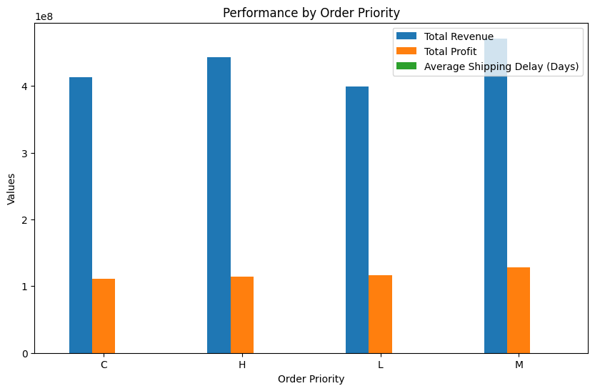

|  | Order Priority | Total Revenue | Total Profit | Average Shipping Delay (Days) |
| --- | --- | --- | --- | --- |
| 0 | C | 4.127747e+08 | 1.112723e+08 | 23.841935 |
| 1 | H | 4.434963e+08 | 1.143994e+08 | 24.169591 |
| 2 | L | 3.994735e+08 | 1.168462e+08 | 25.136095 |
| 3 | M | 4.711623e+08 | 1.281969e+08 | 25.682451 |

```python
df['Order Date'] = pd.to_datetime(df['Order Date'])
df['Ship Date'] = pd.to_datetime(df['Ship Date'])

df['Shipping Delay (Days)'] = (df['Ship Date'] - df['Order Date']).dt.days

priority_performance = df.groupby('Order Priority').agg({
    'Total Revenue': 'sum',
    'Total Profit': 'sum',
    'Shipping Delay (Days)': 'mean'
}).reset_index()

priority_performance.rename(columns={'Shipping Delay (Days)': 'Average Shipping Delay (Days)'}, inplace=True)

priority_performance.set_index('Order Priority')[['Total Revenue', 'Total Profit', 'Average Shipping Delay (Days)']].plot(
    kind='bar',
    figsize=(10, 6)
)

plt.title('Performance by Order Priority')
plt.ylabel('Values')
plt.xlabel('Order Priority')
plt.xticks(rotation=0)
plt.show()

priority_performance
```

This analysis looks at how different order priorities affect Total Revenue, Total Profit, and Average Shipping Delays. It highlights some key differences in how orders are handled depending on their priority level.

- Medium Priority (M)

Total Revenue: 471 million (the highest) Total Profit: 128 million (also the highest) Average Shipping Delay: 25.68 days (the longest delay)

Medium-priority orders bring in the most revenue and profit, but they take the longest to ship. This could be because these orders aren’t urgent, so they may be grouped together to save on shipping costs. Even with slower delivery times, they’re highly profitable—possibly because they involve larger orders or high-margin products.

- High Priority (H)

Total Revenue: 443 million Total Profit: 114 million Average Shipping Delay: 24.17 days

High-priority orders are shipped a bit faster than Medium ones but still take around 24 days. They make solid revenue and profit, though not as much as Medium-priority orders. The faster delivery suggests they are treated as more urgent, but not by a huge margin.

- Critical Priority (C)

Total Revenue: 413 million Total Profit: 111 million (the lowest profit) Average Shipping Delay: 23.84 days (the fastest shipping time)

Critical orders are shipped the fastest, which makes sense since they’re likely time-sensitive. However, they generate the lowest profit, possibly because of extra costs for faster shipping or handling. If prices don’t fully cover these extra expenses, profits naturally drop.

- Low Priority (L)

Total Revenue: 399 million (the lowest revenue) Total Profit: 116 million (surprisingly higher than Critical and High) Average Shipping Delay: 25.13 days

Low-priority orders take a long time to deliver, similar to Medium-priority ones. But they are more profitable than both Critical and High-priority orders. This could be due to cheaper shipping methods, like combining shipments or using lower-cost carriers, which helps save money and increase profit margins, even if revenue is lower.

# **Conclusion**

This project helped me figure out where the company is doing well and where there’s room to improve. I looked at different parts of the sales data to see what’s working and what isn’t.

Office Supplies sell the most and bring in the biggest profit. Cosmetics and Household do okay, but Fruits and Beverages aren’t doing great. The company should either find ways to improve them or maybe drop them.

As for Order Priority, Medium priority orders bring the most profit but take longer to ship. Critical orders ship the fastest but don’t make as much profit. The business should think about whether faster shipping is worth the extra cost.